Visualisation · Géométrie · R

# ggcircular

Visualiser les données directionnelles.

Une extension de ggplot2 pour les données circulaires, axiales et directionnelles.

`ggcircular` est une extension `ggplot2` pour visualiser des données circulaires, axiales et directionnelles. Le package fournit des géométries, statistiques, échelles et thèmes pour travailler avec des angles, orientations, heures de la journée, directions de mouvement et distributions circulaires.

Version CRAN : 0.1.0, publiée le 4 juin 2026.

La version de développement GitHub 0.2.0 ajoute notamment des représentations circulaires-linéaires et circulaires-circulaires sur cylindres et tores. Ces extensions relèvent de la version de développement.

[CRAN](https://cran.r-project.org/web/packages/ggcircular/index.html) [GitHub](https://github.com/AurelienNicosiaULaval/ggcircular) [Documentation](https://aureliennicosiaulaval.github.io/ggcircular/) [Référence](https://aureliennicosiaulaval.github.io/ggcircular/reference/index.html)

## Article associé

Nicosia, A. (2026). *Visualizing directional dependence on cylinders and tori*. *Journal of Data Science, Statistics, and Visualisation*, 6(7). Publié le 1er octobre 2026. [Article et DOI](https://doi.org/10.52933/jdssv.v6i7.181).

## Aperçu visuel

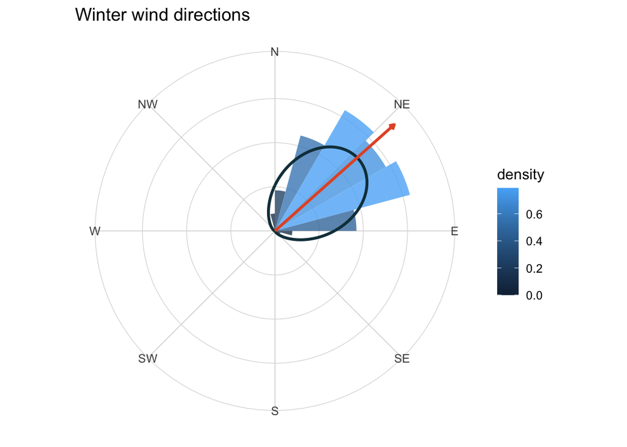

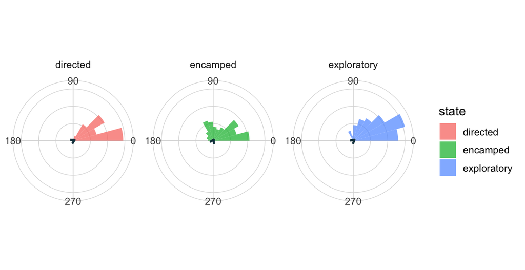

## Exemple d’utilisation

Le code suivant reprend l’esprit du démarrage rapide du package : représenter des directions de vent hivernales avec un diagramme de rose, une densité circulaire et une direction moyenne.

```r
# Load libraries
library(ggplot2)
library(dplyr)
library(ggcircular)

# Plot winter wind directions
wind_directions |>
  filter(season == "winter") |>
  ggplot(aes(x = direction)) +
  geom_rose(
    aes(y = after_stat(density), fill = after_stat(density)),
    bins = 24,
    alpha = 0.78
  ) +
  geom_circular_density(linewidth = 1.1, colour = "#123C4A") +
  geom_mean_direction(
    length = "resultant",
    colour = "#E4572E",
    linewidth = 1.1
  ) +
  scale_x_circular_compass() +
  coord_circular(zero = "north", direction = "clockwise") +
  labs(fill = "densité", title = "Directions de vent en hiver") +
  theme_circular()
```

## À quoi sert ggcircular ?

- créer des diagrammes de rose et des histogrammes circulaires ;
- estimer et afficher des densités circulaires ;
- représenter directions moyennes, arcs de confiance et distributions théoriques ;
- produire des graphiques `ggplot2` reproductibles pour données périodiques, axiales ou directionnelles.